# NACHO

A NAnoString quality Control dasHbOard

Mickaël Canouil, Ph.D., Gerard A. Bouland and Roderick C. Slieker, Ph.D.

18 November 2026

[figure not shown]

# 1 Installation

```r
# Install the release from CRAN:
install.packages("NACHO")

# Or install the development version from R-universe:
install.packages(
  "NACHO",
  repos = c("https://mcanouil.r-universe.dev", "https://cloud.r-project.org")
)

# Or install the latest commit from GitHub with pak:
# install.packages("pak")
pak::pak("mcanouil/NACHO")
```

```r
# Load NACHO
library(NACHO)
```

# 2 Overview

*NACHO* (**NA**noString quality **C**ontrol das**H**b**O**ard) works with NanoString nCounter data. An nCounter assay measures messenger RNA and micro RNA (mRNA/miRNA) expression with fluorescent barcodes. Each barcode is assigned to an mRNA or miRNA, and it is counted after it binds its target. Each count of a barcode therefore shows how much of its target is present.

*NACHO* loads, visualizes and normalizes the exported nCounter data, and it helps you to check its quality. It shows quality control metrics, the expression of control genes, principal components and sample-specific size factors in an interactive web application.

Two functions summarize and visualize the RCC files:

- The `load_rcc()` function preprocesses the data.
- The `visualise()` function starts a [Shiny-based dashboard](https://shiny.posit.co/) with all relevant QC plots.

*NACHO* also has a `normalise()` function. It calculates the sample-specific size factors again and normalizes the data.

- The `normalise()` function returns a `nacho` object that holds your settings, the raw counts and the normalized counts.

Since v0.6.0, *NACHO* has two more functions:

- The `render()` function writes a full quality control report with Quarto, as an HTML or PDF file, from the result of `load_rcc()` or `normalise()`.
- The `autoplot()` function draws the quality control metrics of `visualise()` and `render()`.

For more information, see `vignette("NACHO")` and the articles on the package website.

Canouil M, Bouland GA, Bonnefond A, Froguel P, ’t Hart LM, Slieker RC (2020). “NACHO: an R package for quality control of NanoString nCounter data.” *Bioinformatics*, **36**(3), 970–971. ISSN 1367-4803. [doi:10.1093/bioinformatics/btz647](https://doi.org/10.1093/bioinformatics/btz647).

```
@Article{Canouil2020,
  title = {{NACHO}: an {R} package for quality control of {NanoString} {nCounter} data},
  author = {Mickaël Canouil and Gerard A. Bouland and Amélie Bonnefond and Philippe Froguel and Leen M. {'t Hart} and Roderick C. Slieker},
  journal = {Bioinformatics},
  year = {2020},
  month = {feb},
  volume = {36},
  number = {3},
  pages = {970--971},
  issn = {1367-4803},
  doi = {10.1093/bioinformatics/btz647},
}
```

# 3 Load RCC files

*NACHO* ships three small datasets in `inst/extdata`, so every chunk below runs offline. `GSE178516` holds six mRNA samples measured with the PanCancer IO 360 panel. `GSE270837` holds six miRNA samples. `GSE346526` holds six mRNA samples in RCC files that nSolver 4.0.1.8 wrote. All three come from the NCBI GEO public database (Barrett et al. 2013), and each folder has a `samplesheet.csv` whose `IDFILE` column holds the exact name of each RCC file.

`load_rcc()` takes the folder with the RCC files, the samplesheet and the name of the identifier column. It reads the files, computes the quality-control metrics, normalises the counts and returns a `nacho` object. With only six samples, there are at most five principal components, so we ask for five. The RCC files do not name the instrument, so we say it is an nCounter MAX, which sets the binding density limits.

```r
data_directory <- system.file("extdata", "GSE178516", package = "NACHO")
nacho <- load_rcc(
  data_directory = data_directory,
  ssheet_csv = file.path(data_directory, "samplesheet.csv"),
  id_colname = "IDFILE",
  instrument = "max",
  n_comp = 5
)
## ℹ Reading 6 RCC files
## ✔ Reading 6 RCC files [31ms]
##
## ℹ Assembling 6 samples
## ✔ Assembling 6 samples [25ms]
##
## ℹ Computing quality-control metrics and normalising
## ✔ Computing quality-control metrics and normalising [32ms]
##
print(nacho)
## <nacho> 6 samples, 784 probes, from single-sample RCC files
## Normalisation: GEO, with 20 housekeeping genes
## Flagged samples: 0 of 6
## Created with NACHO 3.0.2
```

# 4 Read the object

Four accessors give you the content of a `nacho` object as plain matrices and data frames. `nacho_counts()` returns the counts, with one row per probe and one column per sample. Pass `normalised = TRUE` for the normalised counts, and `log2 = TRUE` for `log2(count + 1)`.

```r
head(nacho_counts(nacho), n = c(5, 3))
##        GSM5393247_S02.RCC.gz GSM5393248_S13.RCC.gz GSM5393250_S15.RCC.gz
## A2M                      255                   549                  5061
## ACVR1C                    11                    52                   184
## ADAM12                     1                     8                    14
## ADGRE1                     2                     0                    26
## ADM                       62                   181                   117
```

`nacho_samples()` has one row per sample, with the samplesheet columns, the RCC header fields and the quality-control metrics.

```r
head(nacho_samples(nacho)[, c("IDFILE", "title", "CartridgeID", "BD", "FoV")], n = 3)
##                  IDFILE       title  CartridgeID   BD   FoV
## 1 GSM5393247_S02.RCC.gz Patient S02 Lynch Lauf 1 0.34  99.8
## 2 GSM5393248_S13.RCC.gz Patient S13 Lynch Lauf 1 0.38 100.0
## 3 GSM5393250_S15.RCC.gz Patient S15 Lynch Lauf 1 0.62  99.8
```

`nacho_probes()` has one row per probe, with its code class, its detection rate and whether it is a housekeeping gene.

```r
head(nacho_probes(nacho), n = 3)
##    CodeClass   Name   Accession detection_rate is_housekeeping is_excluded
## 1 Endogenous    A2M NM_000014.4            1.0           FALSE       FALSE
## 2 Endogenous ACVR1C NM_145259.2            1.0           FALSE       FALSE
## 3 Endogenous ADAM12 NM_003474.5            0.5           FALSE       FALSE
table(nacho_probes(nacho)[["CodeClass"]])
##
##   Endogenous Housekeeping     Negative     Positive
##          750           20            8            6
```

`nacho_qc()` has the quality-control table, one row per sample.

```r
head(nacho_qc(nacho)[, c("IDFILE", "BD", "FoV", "PCL", "LoD")], n = 3)
##                  IDFILE   BD   FoV     PCL   LoD
## 1 GSM5393247_S02.RCC.gz 0.34  99.8 0.98757 11.42
## 2 GSM5393248_S13.RCC.gz 0.38 100.0 0.98809 21.76
## 3 GSM5393250_S15.RCC.gz 0.62  99.8 0.98463 11.12
```

Earlier versions of *NACHO* kept all of this in a `$nacho` data frame. That slot is gone, and the article “Moving from NACHO 2” on the [package website](https://m.canouil.dev/NACHO/) maps each old element to its accessor.

# 5 Quality control

A sample is flagged when a metric falls outside its limits. `nacho_thresholds()` builds those limits. The default `"nsolver"` preset follows the nCounter knowledge base, and `preset = "legacy"` reproduces the limits of *NACHO* 2.

```r
str(nacho_thresholds(), max.level = 1)
## List of 13
##  $ preset               : chr "nsolver"
##  $ instrument           : chr "max"
##  $ BD                   : num [1:2] 0.05 2.25
##  $ FoV                  : num 75
##  $ PCL                  : num 0.95
##  $ LoD                  : num 2
##  $ Positive_factor      : num [1:2] 0.3 3
##  $ House_factor         : num [1:2] 0.1 10
##  $ Housekeeping_detected: num 3
##  $ Ligation_order       : num 1
##  $ Ligation_R2          : num 0.95
##  $ Ligation_NEG         : num [1:2] -Inf 0
##  $ Haemolysis           : num [1:2] -Inf Inf
```

Each `*_status` column of `nacho_qc()` holds the result of one check. Three more columns summarise them: `status`, `n_flags` and `reason`.

```r
nacho_qc(nacho)[, c("IDFILE", "status", "n_flags", "reason")]
##                  IDFILE status n_flags reason
## 1 GSM5393247_S02.RCC.gz   pass       0   <NA>
## 2 GSM5393248_S13.RCC.gz   pass       0   <NA>
## 3 GSM5393250_S15.RCC.gz   pass       0   <NA>
## 4 GSM5393251_S16.RCC.gz   pass       0   <NA>
## 5 GSM5393267_S46.RCC.gz   pass       0   <NA>
## 6 GSM5393268_S47.RCC.gz   pass       0   <NA>
```

All six samples pass. To use the legacy limits, give `load_rcc()` the preset, or pass new limits to `normalise()`.

```r
legacy <- load_rcc(
  data_directory = data_directory,
  ssheet_csv = file.path(data_directory, "samplesheet.csv"),
  id_colname = "IDFILE",
  instrument = "max",
  n_comp = 5,
  preset = "legacy"
)
## ℹ Reading 6 RCC files
## ✔ Reading 6 RCC files [17ms]
##
## ℹ Assembling 6 samples
## ✔ Assembling 6 samples [17ms]
##
## ℹ Computing quality-control metrics and normalising
## ✔ Computing quality-control metrics and normalising [21ms]
##
table(nacho_qc(legacy)[["status"]])
##
## pass
##    6
```

`write_thresholds()` saves a set of limits to a YAML file, and `read_thresholds()` reads the file back. With this file, you can use the same limits for each study. The **Export** page of the app writes the same file.

```r
thresholds_file <- tempfile(fileext = ".yml")
write_thresholds(nacho_thresholds(preset = "legacy"), thresholds_file)
legacy <- normalise(nacho, outliers_thresholds = read_thresholds(thresholds_file))
## Normalising again with new settings:
## • thresholds preset
table(nacho_qc(legacy)[["status"]])
##
## pass
##    6
```

# 6 Normalise

`normalise()` normalises a `nacho` object again with new settings and returns a new object. The default scales the samples with the geometric mean of the positive controls (`"GEO"`). `"GLM"` fits a Poisson model to the positive and negative controls instead.

```r
geo_norm <- normalise(nacho, normalisation_method = "GEO")
## The settings are the same as in the input, so `normalise()` returns it
## unchanged.
glm_norm <- normalise(nacho, normalisation_method = "GLM")
## Normalising again with new settings:
## • normalisation_method
head(nacho_counts(glm_norm, normalised = TRUE), n = c(3, 3))
##        GSM5393247_S02.RCC.gz GSM5393248_S13.RCC.gz GSM5393250_S15.RCC.gz
## A2M              1511.749015             935.45044           2951.662509
## ACVR1C             65.212703              88.60368            107.311974
## ADAM12              5.928428              13.63134              8.165042
```

Background handling has two arguments. `background` chooses how to estimate each sample’s background from its negative controls, for example `"mean_2sd"`. `background_mode` chooses what to do with it: `"threshold"` raises lower counts to the background, and `"subtract"` removes it.

```r
background <- normalise(
  nacho,
  background = "mean_2sd",
  background_mode = "subtract"
)
## Normalising again with new settings:
## • background
## • background_mode
```

`exclude_outliers()` drops the flagged samples and normalises the remaining ones again. Here nothing is flagged, so the object stays as it is.

```r
cleaned <- exclude_outliers(geo_norm)
## No sample is flagged, so nothing is removed.
```

# 7 miRNA panels

`load_rcc()` recognises miRNA panels from their probes. The folder `GSE270837` holds six samples from such a panel, measured on an nCounter SPRINT, so we load them with the SPRINT limits.

```r
mirna_directory <- system.file("extdata", "GSE270837", package = "NACHO")
mirna <- load_rcc(
  data_directory = mirna_directory,
  ssheet_csv = file.path(mirna_directory, "samplesheet.csv"),
  id_colname = "IDFILE",
  instrument = "sprint",
  n_comp = 5
)
## ℹ Reading 6 RCC files
## ✔ Reading 6 RCC files [20ms]
##
## ℹ Assembling 6 samples
## ✔ Assembling 6 samples [16ms]
##
## ℹ Computing quality-control metrics and normalising
## ✔ Computing quality-control metrics and normalising [17ms]
##
print(mirna)
## <nacho> 6 samples, 828 probes, from single-sample RCC files
## Normalisation: GEO, without housekeeping genes
## Flagged samples: 0 of 6
## Created with NACHO 3.0.2
table(nacho_probes(mirna)[["CodeClass"]])
##
##  Endogenous1 Housekeeping     Ligation     Negative     Positive      SpikeIn
##          798            5            6            8            6            5
```

The housekeeping mRNAs of a miRNA panel sit at the background level, so housekeeping normalisation is off by default. It only switches on when you pass `housekeeping_genes` or set `housekeeping_predict = TRUE`. The miRNA methods of `normalisation_method` (`"stable_mirna"`, `"total_mirna"`, `"spike_in"` and `"ligation"`) scale the samples with miRNAs or with the spike-in and ligation controls instead.

`Ligation_NEG` flags a sample when its largest ligation negative control is above the detection limit. Whole-blood RNA raises the ligation negative `LIG_NEG_A` together with red blood cell miRNAs such as miR-451a. Thus most samples of a whole-blood study can fail `Ligation_NEG` without a fault in the assay. When more than half of the samples fail, `load_rcc()` warns about this pattern. For whole-blood samples, set a higher upper bound for `Ligation_NEG` and normalise again. The bound below is an example; choose it from the `Ligation_NEG` values of your study.

```r
thresholds <- nacho_thresholds(instrument = "sprint")
thresholds[["Ligation_NEG"]] <- c(-Inf, 100)
mirna <- normalise(mirna, outliers_thresholds = thresholds)
```

# 8 Plots

`autoplot()` draws any quality-control figure of the app and of the report. It takes the object and a `type`, and returns a `ggplot` object.

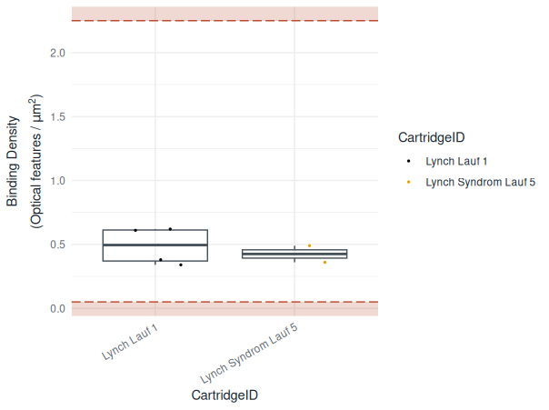

```r
autoplot(nacho, type = "BD")
```

Every `type` takes the same arguments: `colour`, `size`, `show_legend`, `show_outliers`, `outliers_factor`, `outliers_labels` and `dark`. A few plot types ignore some of them, and `?autoplot.nacho` says which. The relative log expression of the normalised counts shows whether the samples line up.

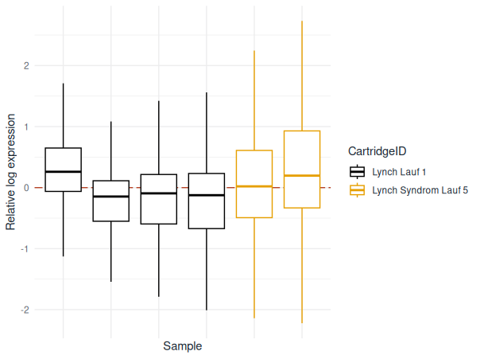

```r
autoplot(geo_norm, type = "RLE")
```

The first two principal components show how the samples spread.

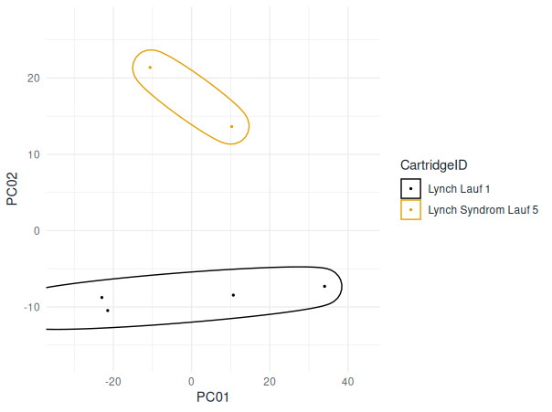

```r
autoplot(geo_norm, type = "PCA12")
```

This table lists every plot type.

| `type` | What it shows |
| --- | --- |
| `"BD"` | Binding Density. |
| `"FoV"` | Field of View (imaging). |
| `"PCL"` | Positive Control Linearity. |
| `"LoD"` | Limit of Detection. |
| `"Positive"` | Positive controls. |
| `"Negative"` | Negative controls. |
| `"Housekeeping"` | Housekeeping genes. |
| `"PN"` | Positive controls against negative controls. |
| `"ACBD"` | Average counts against binding density. |
| `"ACMC"` | Average counts against median counts. |
| `"PCA12"` | Principal component 1 against 2. |
| `"PCAi"` | Scree plot of the principal components. |
| `"PCA"` | Planes of the first principal components. |
| `"PFNF"` | Positive factor against negative factor. |
| `"HF"` | Housekeeping factor. |
| `"NORM"` | Normalisation factor. |
| `"Stability"` | geNorm stability of the housekeeping genes. |
| `"RLE"` | Relative log expression of the normalised endogenous genes. |
| `"BatchFactors"` | Normalisation factors by cartridge. |
| `"PCBatch"` | Share of each principal component explained by cartridge and date. |

# 9 Report

`render()` builds a report with every quality-control metric and a description of each. It writes a self-contained HTML file, or a Typst PDF with `format = "typst"`, and returns the path. It needs Quarto 1.9.18 or newer. The article “The Quality-Control Report” on the [package website](https://m.canouil.dev/NACHO/) shows what the report looks like.

```r
render(nacho, format = "html", output_dir = tempdir())
```

# 10 App

`visualise()` opens the interactive app. The sidebar holds the quality-control thresholds and the normalisation settings for every page. When you click Done, `visualise()` returns the tuned object to your R session.

[figure not shown]

```r
tuned <- visualise(nacho)
```

The article “Explore quality control in the app” on the [package website](https://m.canouil.dev/NACHO/) walks through every page of the app.

# 11 Bioconductor

`as_summarized_experiment()` converts a `nacho` object into a `SummarizedExperiment`, and `as_nacho()` converts it back. This needs the *SummarizedExperiment* package from Bioconductor.

```r
se <- as_summarized_experiment(nacho)
se
## class: SummarizedExperiment
## dim: 784 6
## metadata(1): nacho
## assays(2): counts normalised
## rownames(784): A2M ACVR1C ... POS_E(0.5) POS_F(0.125)
## rowData names(6): CodeClass Name ... is_housekeeping is_excluded
## colnames(6): GSM5393247_S02.RCC.gz GSM5393248_S13.RCC.gz ...
##   GSM5393267_S46.RCC.gz GSM5393268_S47.RCC.gz
## colData names(42): IDFILE geo_accession ... PC04 PC05
```

# References

Barrett, Tanya, Stephen E. Wilhite, Pierre Ledoux, et al. 2013. “NCBI GEO: Archive for Functional Genomics Data Sets—Update.” *Nucleic Acids Research* 41 (January): D991–95. https://doi.org/10.1093/nar/gks1193.